# 2024 Presidential Debates. Text Analysis

## Goals

### General Goal

Establish and compare the main trends in the candidates’ arguments.

### Specific Goals

1. Quantitative: Number of words used by each candidate.
2. Most used words.
3. Negative and positive associations of the most used words.
4. Within debate comparison: Which words were used the most by each candidate? Comparison in the use of similar words, if any.
5. Between debate comparison: Differences by party. For Trump, differences in time.

## Tasks

[output not shown]

## Results

### Count the Words

#### Number of Words by Candidate/Debate

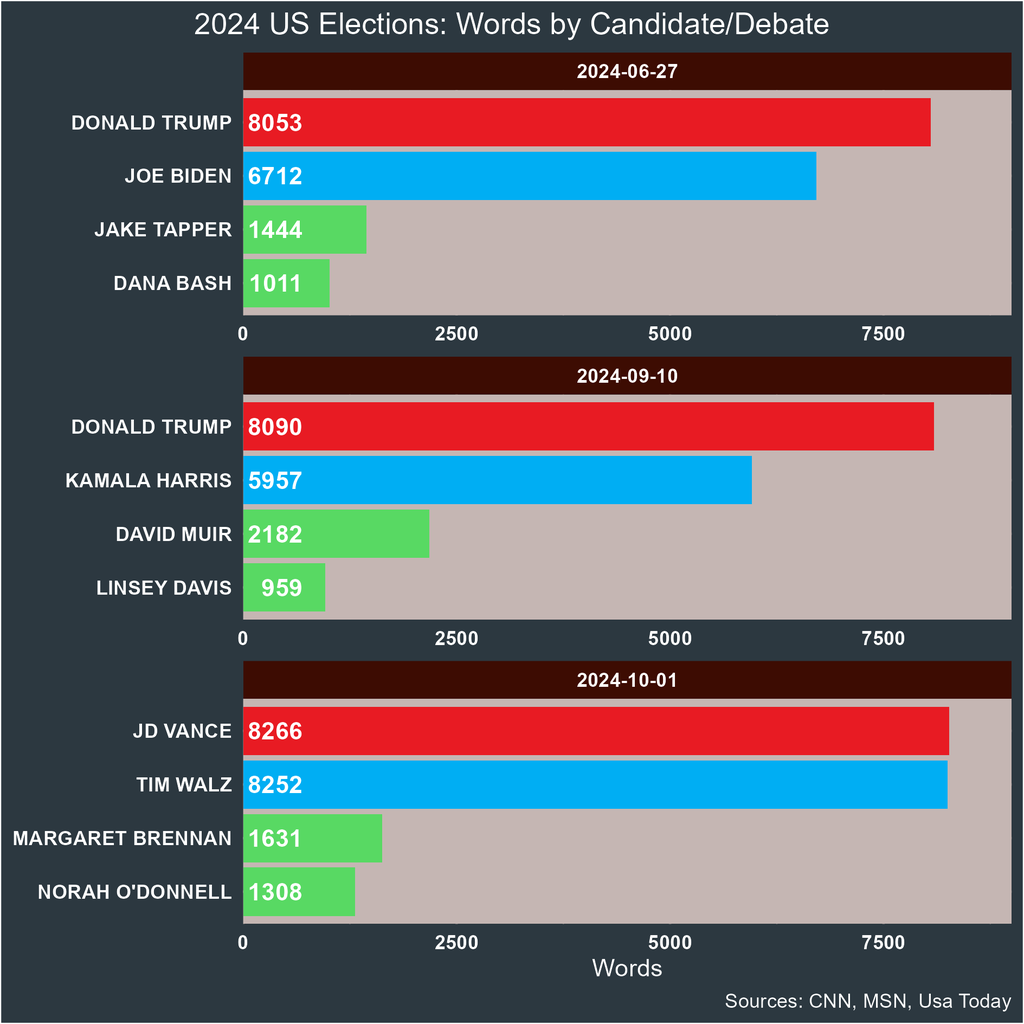

### Most Used Words with Stop Words

#### Goals

1. Number of unique words by candidate and debate.
2. Vocabulary diversity by candidate: number of unique words relative to the total number of words (DW/TW).
3. Number of relevant words (after applying the stop-words).

#### Tasks

1. Unique words. 1.1. Create a data frame with the total number of words (including numbers) used by candidates in the debate. 1.2. This task includes filtering the data (no journalists), grouping by debate and candidate, and counting the number of rows. 1.3. Build a bar graph with the results. Start with a new ggplot graph. First, we must create a column with the candidates’ names and the month of the debate (because Trump participated twice) and use this column as the X-axis.

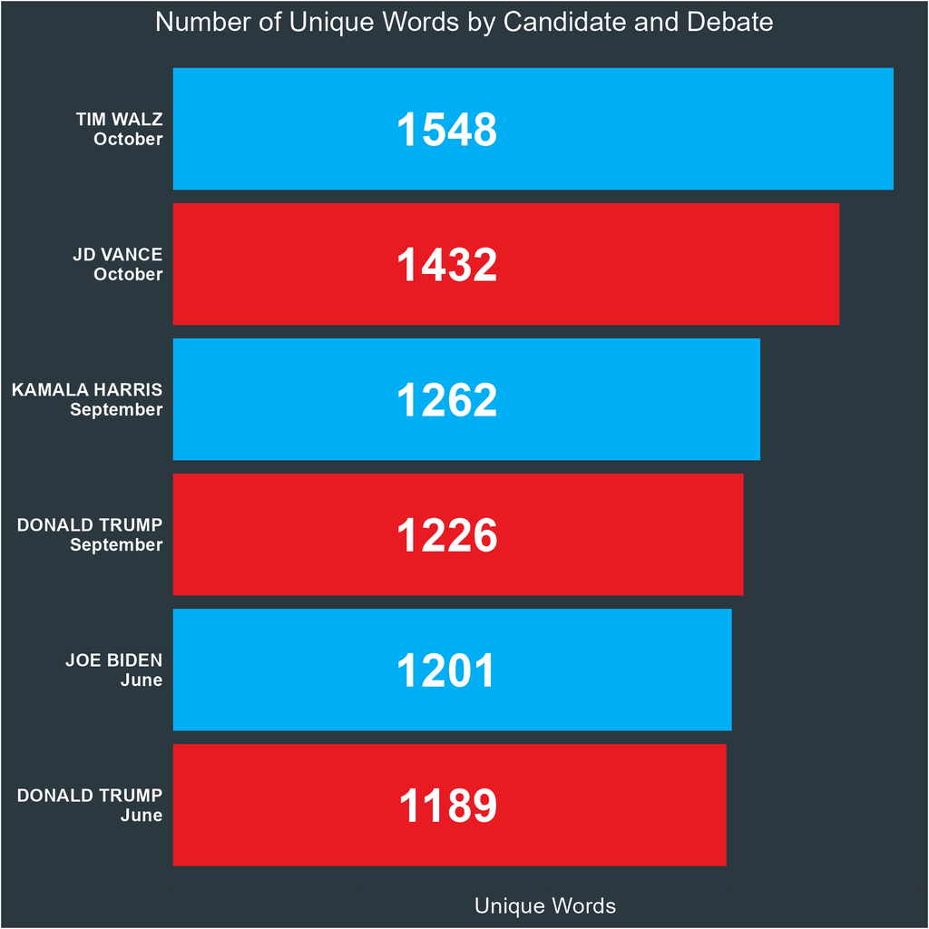

2. Vocabulary diversity. 2.1. Starting with “debates_2024,” filter the candidates and create a column candidate-month. Name this new data frame “debates_2024_candidate_month.” 2.2. With “debates_2024_candidate_month,” build the data frame “debates_2024_candidate_month_total_words.” Group the data using the candidate-month column and create a column with the total of words (summarise command from dplyr). 2.3. With “debates_2024_candidate_month,” build the data frame “debates_2024_candidate_month_unique_words.” Group the data using the candidate-month column, and count the unique words (using the count command from dplyr). 2.4. Joint both data frames: “debates_2024_candidate_month_total_words” and “debates_2024_candidate_month_unique_words.” 2.5. Apply the formula in a new column. 2.6. Build the corresponding graph.

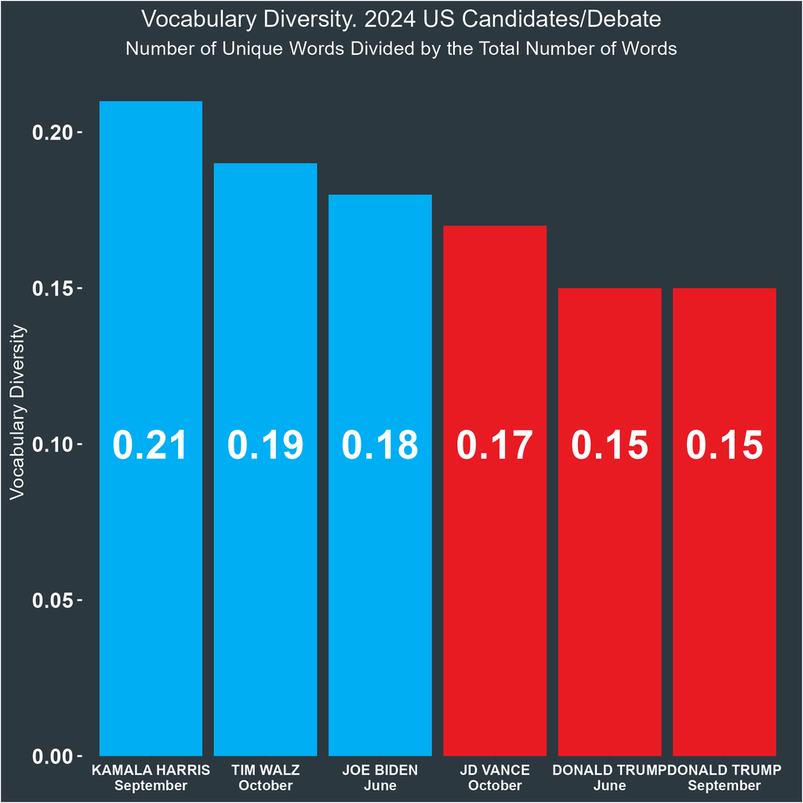

3. Number of relevant words. 3.1. Improve the stop words: no numbers, no personal pronouns, keep the verbs. 3.2. Apply the anti-join command to the data frame “debates_2024.” 3.3. Repeat tasks in the section “Unique words.”

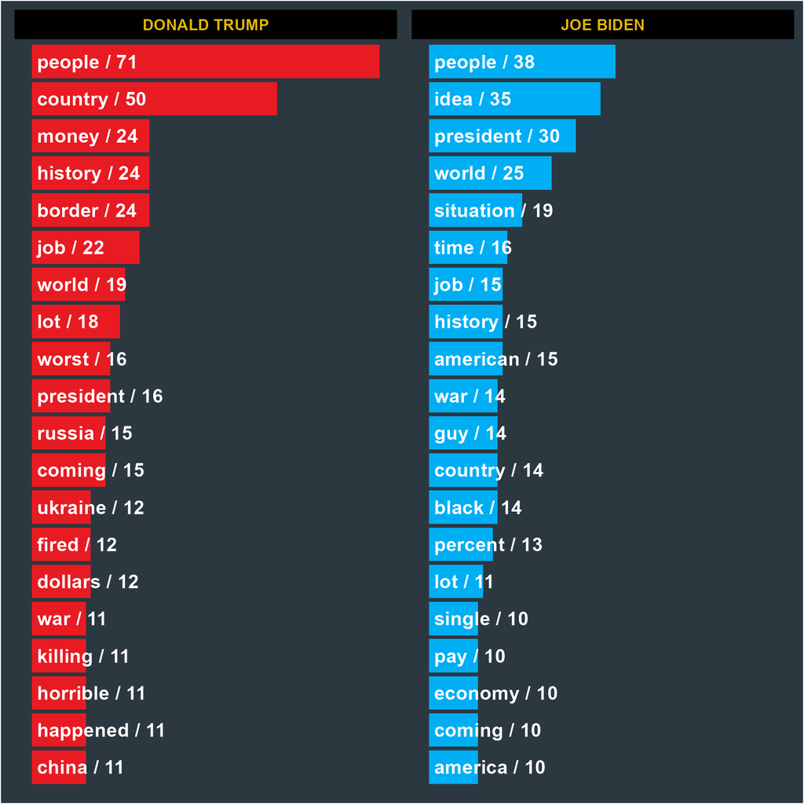

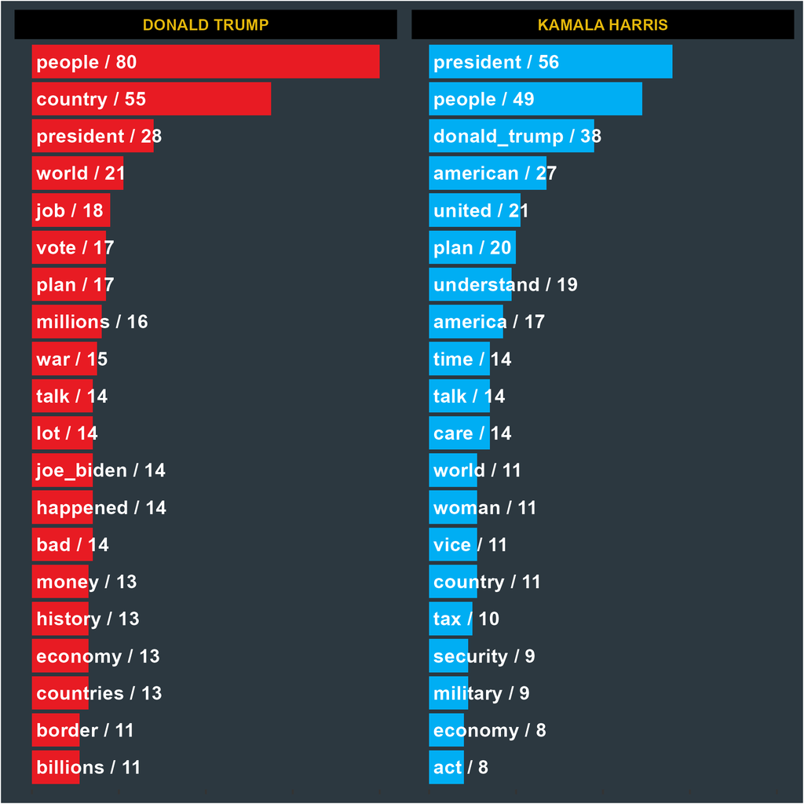

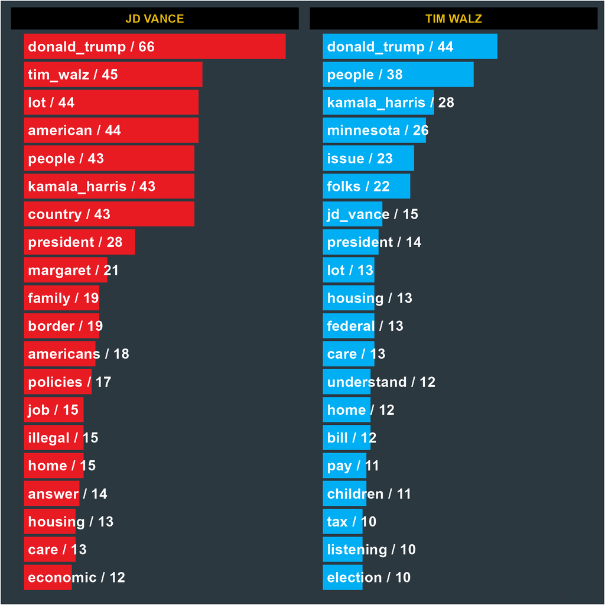

### Similarities in the discourses

$\binom{6}{2} =$ $\frac{6!}{2!(6-2)!} =$ $\ 15$

## References

1. Schloss, P. [Connecting an Existing RStudio Project to Git and GitHub (CC145)](https://www.youtube.com/watch?v=bUoN85QvC10).
2. Silge, J. and Robinson, D. [Text Minning with R: A Tidy Approach](https://www.tidytextmining.com/).

## License

[Text Analysis of US 2024 Presidential Debates Using R](https://github.com/ortizpalanques1/debates_US_2024) by [Marco Ortiz Palanques](https://www.linkedin.com/in/marco-ortiz-palanques-710a556b/) is licensed under [CC BY-NC 4.0](https://creativecommons.org/licenses/by-nc/4.0/?ref=chooser-v1)